# Rによるデータ同化と機械学習

榎本剛

2025-08-27

# Rとは

## Rは統計言語を超越

Gagolewski (2024)

Let’s get one thing straight: R is not just a statistical package. It is a general-purpose, high-level programming language that happens to be very powerful for numerical, data-intense computing activities of any kind. It offers extensive support for statistical, machine learning, data analysis, data wrangling, and data visualisation applications, but there is much more.

## Why use R for oceanographic analysis?

> With its broad statistical support, R is a natural choice for oceanographers in the biological, chemical and geological sub-disciplines. However, some physical oceanographers have remained attached to Matlab, … Lately, this has been changing, as oceanographers turn to open-source systems such as Python and R. A particular strength of R is its provision of many powerful and well-vetted packages for handling specialized calculations. The [oce](https://dankelley.github.io/oce/) package is a prime example.

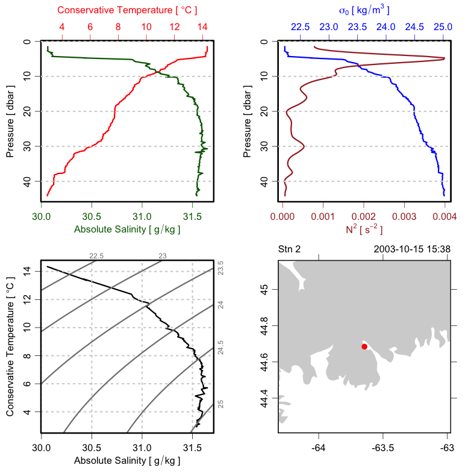

## Rは何なのか

- 思いつきの確認、データ探索、高速プロトタイプの道具
- Python + pandas + matplotlibやJulia、MATLABに相当するプログラミング環境
- 再現性のある科学 (Schwab et al. (2000);Gentleman and Temple Lang (2007);Marwick et al. (2018))

## Rの特徴

- 基本的な数学函数、統計、行列計算、描画を含む。
- 添字は1始まり。負の添字は削除。
- 配列`array()`や行列`matrix()`は列優先で数式と対応。
- （緩い）函数型 `func()`
- Copy on modify
- 環境構築のしやすさ
  - バッケージ [CRAN](https://ftp.yz.yamagata-u.ac.jp/pub/cran/)
  - [WindowsのRtools](https://www.dpac.dpri.kyoto-u.ac.jp/enomoto/dass2025/setup.html)でコンパイル環境まで整う。

# Pythonに疲れてない？

## 正規分布

- Python
- R

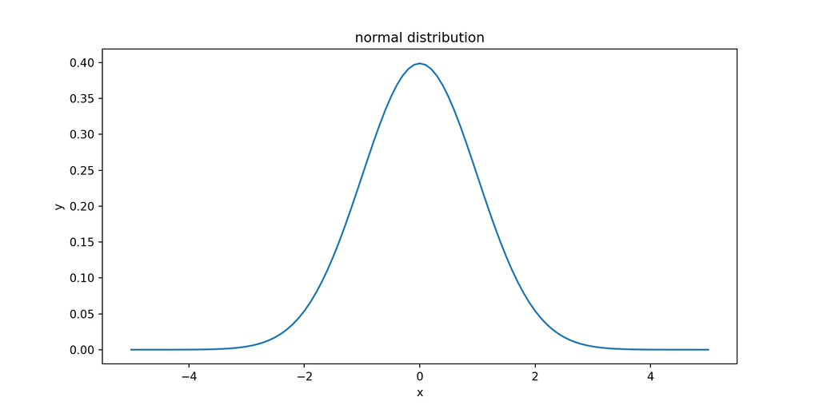

```python
import numpy as np
from scipy.stats import norm
import matplotlib.pyplot as plt

fig, ax = plt.subplots()

x = np.linspace(-5, 5, 101)
y = norm.pdf(x)
ax.plot(x, y)
ax.set_title("normal distribution")
ax.set_xlabel("x")
ax.set_ylabel("y")
plt.show()
```

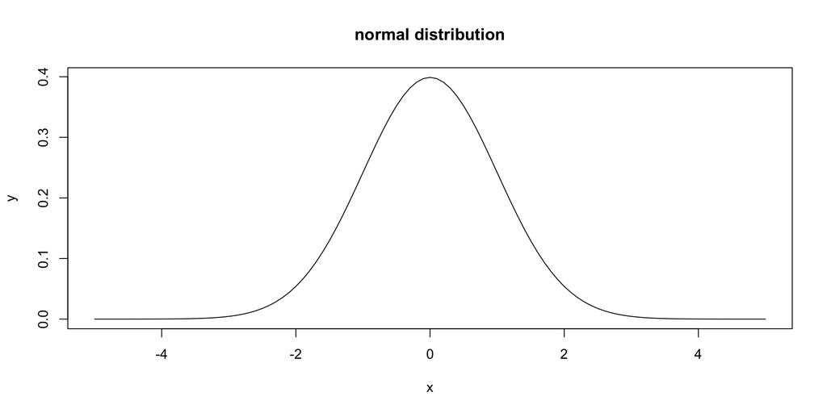

```r
curve(dnorm, -5, 5, main="normal distribution", xlab="x", ylab="y")
```

## アンサンブル偏差

- R
- Python

```r
(x <- matrix(0:11, ncol=4))
```

```
     [,1] [,2] [,3] [,4]
[1,]    0    3    6    9
[2,]    1    4    7   10
[3,]    2    5    8   11
```

```r
(xbar <- apply(x, 1, mean)) # rowMeans(x)
```

```
[1] 4.5 5.5 6.5
```

```r
x - xbar # sweep(x, 1, xbar)
```

```
     [,1] [,2] [,3] [,4]
[1,] -4.5 -1.5  1.5  4.5
[2,] -4.5 -1.5  1.5  4.5
[3,] -4.5 -1.5  1.5  4.5
```

```python
x = np.arange(12).reshape([4, 3]).transpose()
print(x)
```

```
[[ 0  3  6  9]
 [ 1  4  7 10]
 [ 2  5  8 11]]
```

```python
xbar = x.mean(axis=1)
print(xbar)
```

```
[4.5 5.5 6.5]
```

```python
x - xbar[:,None]
```

```
array([[-4.5, -1.5,  1.5,  4.5],
       [-4.5, -1.5,  1.5,  4.5],
       [-4.5, -1.5,  1.5,  4.5]])
```

## Rと私

- 渋谷政昭・柴田里程, 1992: [Sによるデータ解析](https://www.kyoritsu-pub.co.jp/book/b10005973.html)
- アンサンブル予報の父、経田さんにRを勧められる。
- rglやRMarkdownがきっかけで、2019年頃からRを再び使い始める。
- 2023年からILASセミナーはPythonからRに。
- 2024・2025年データ同化夏の学校の課題をRで書く。

# Rの環境

## CRAN

[figure not shown]

## RStudio

[figure not shown]

## Jupyter

```r
install.packages("IRkernel")
installspec()
```

[figure not shown]

## Google colaboratory

[figure not shown]

## Rでできること

[figure not shown]

[Rによる気象データサイエンス](https://www.dpac.dpri.kyoto-u.ac.jp/enomoto/rmetds)

- テキスト処理 [stringi](https://stringi.gagolewski.com/), [stringx](https://stringx.gagolewski.com/), [stringr](https://stringr.tidyverse.org/)
- 回帰分析、主成分分析 [SpectrA](https://spectralib.org/)
- データ同化 夏学[2024](https://www.dpac.dpri.kyoto-u.ac.jp/enomoto/dass2024/)、[2025](https://tenomoto.github.io/dass2025/)
- モデル: 前線形成、Poisson方程式、Lorenz-96
- 機械学習、[画像処理](https://dahtah.github.io/imager/imager.html)、3D可視化[rgl](https://dmurdoch.github.io/rgl/)
- 他の言語とのインターフェース

## R中心生活

[figure not shown]

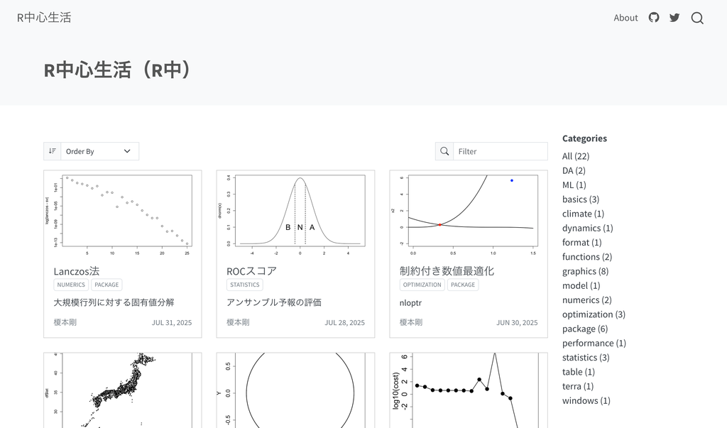

## 線型回帰

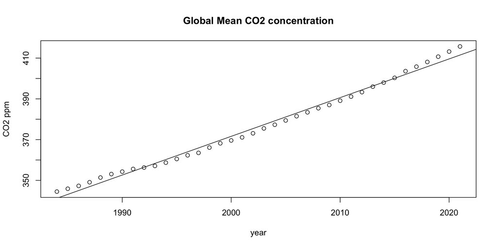

```r
df <- read.csv("co2_annual_20221026.csv")
lm.co2 <- lm(df$co2.global.mean.ppm. ~ df$year)
plot(df$year, df$co2.global.mean.ppm.,
     main="Global Mean CO2 concentration",
     xlab="year", ylab="CO2 ppm")
abline(lm.co2)
```

## 3次元描画

[rgl](https://cran.r-project.org/web/packages/rgl/index.html)

[interactive chart not shown]

## NCEP再解析

[terra](https://rspatial.github.io/terra/reference/terra-package.html)とRNetCDF

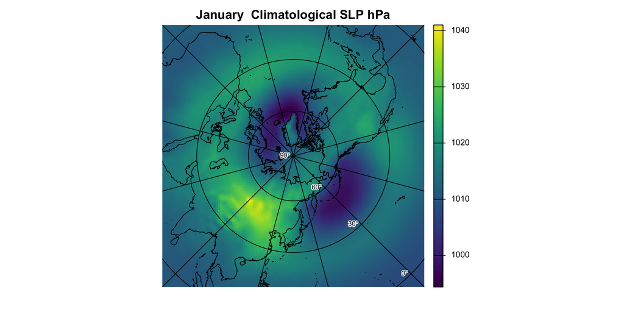

## 奥能登豪雨

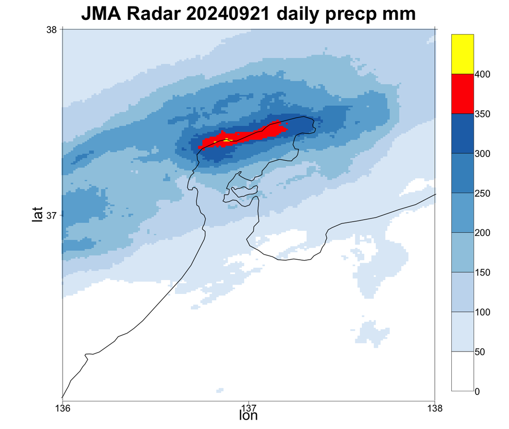

## 湿潤函数

[figure not shown]

## Lorenz-96

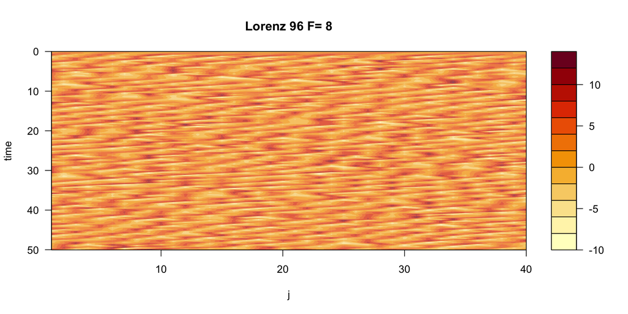

```r
l96 <- function(x, F) {
  n <- length(x)
  (x[c(2:n, 1)] - x[c(n-1, n, 1:(n-2))]) * x[c(n, 1:(n-1))] - x + F
}

rk4 <- function(f, x, dt, opts) {
  k1 <- f(x, opts)
  k2 <- f(x + 0.5 * dt * k1, opts)
  k3 <- f(x + 0.5 * dt * k2, opts)
  k4 <- f(x + dt * k3, opts)
  x + (k1 + 2 * k2 + 2 * k3 + k4) * dt / 6
}

nj <- 40
nstep <- 1001
x.hist <- matrix(0, nj, nstep)
x <- rnorm(nj)
F <- 8
dt <- 0.05
for (i in 1:nstep-1) {
  x <- rk4(l96, x, dt, F)
  x.hist[,i] <- x
}

t <- seq(0, nstep*dt, length.out=nstep)
filled.contour(1:nj, t, x.hist, nlevel=11, main=paste("Lorenz 96 F=", F),
               ylim=rev(range(t)), xlab="j", ylab="time")
```

# Rで機械学習?

## Rの機械学習ライブラリ

- [CRAN TaskView](https://cran.r-project.org/web/views/MachineLearning.html)
- [e1071](https://cran.r-project.org/web/packages/e1071/): 潜在クラス解析、短時間フーリエ解析、ファジークラスタリング、SVM、最短経路計算、バッグドクラスタリング、単純ベイズ分類、一般化k近傍
- [kernlab](https://cran.r-project.org/web/packages/kernlab/): カーネル学習。分類（SVM）、回帰（分位点回帰、ガウス過程回帰）、 クラスタリング（スペクトラルクラスタリング）異常検知、次元削減（カーネルPCA）、最適化（二次計画法ソルバ）
- [caret](https://topepo.github.io/caret/): 分類、回帰、訓練

## 自動微分と数値最適化

[torch for R](https://torch.mlverse.org/) 自動微分を使って  
L-BFGSで数値最適化

```r
library(torch)

rosenbrock <- function(x, y, a = 1, b = 100) {
  (a - x)^2 + b * (y - x^2)^2
}

x <- torch_tensor(c(-1, -1), requires_grad = TRUE)

optimizer <- optim_lbfgs(x, line_search_fn = "strong_wolfe")

calc_loss <- function() {
  optimizer$zero_grad()
  value <- rosenbrock(x[1], x[2])
  cat("value is:", as.numeric(value), "\n")
  value$backward()
  value
}

num_iterations <- 2
tol <- 1e-10
xhist <- as.numeric(x)
for (i in 1:num_iterations) {
  cat("\n", "iteration:", i, "\n")
  optimizer$step(calc_loss)
  cat("x=", as.numeric(x), "\n")
  xhist <- rbind(xhist, as.numeric(x))
}
```

```
 iteration: 1
value is: 404
value is: 62.32629
value is: 30.0694
value is: 2.630802
value is: 1.178554
value is: 1.15742
value is: 1.132393
value is: 1.00142
value is: 1.091282
value is: 0.6181912
value is: 0.8905501
value is: 0.6098283
value is: 0.5655912
value is: 0.3922533
value is: 0.2774411
value is: 1.417702
value is: 0.2190705
value is: 0.1747326
value is: 0.1380794
value is: 0.08087045
value is: 0.05257415
value is: 0.1490689
value is: 0.0400695
value is: 0.02954894
value is: 0.01238139
x= 0.9039377 0.8114879

 iteration: 2
value is: 0.01238139
value is: 0.006821597
value is: 0.002873288
value is: 0.001204705
value is: 0.0006028978
value is: 4.76946e-05
value is: 2.687239e-06
value is: 5.929914e-08
value is: 1.555293e-09
value is: 3.588241e-13
x= 0.9999999 0.9999998
```

```r
x <- seq(-1, 2, 0.01)
y <- seq(-1, 2, 0.01)
z <- outer(x, y, rosenbrock)
```

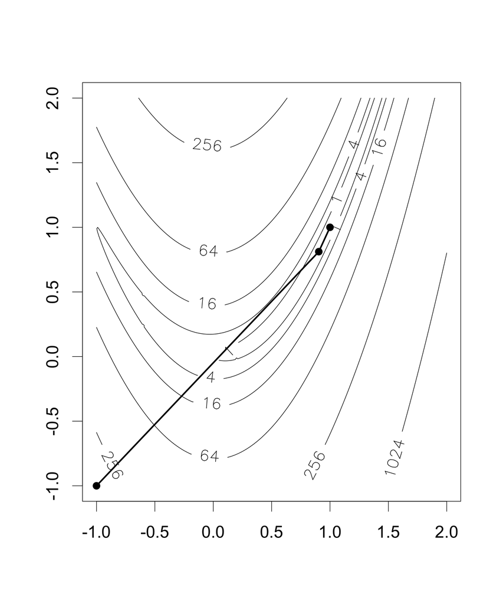

## フーリエニューラル演算子

Li et al. (2021)

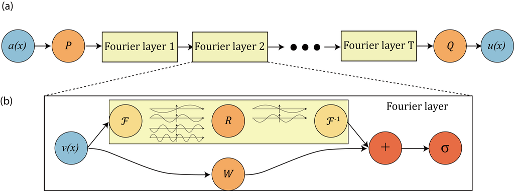

## FNO in torch for R

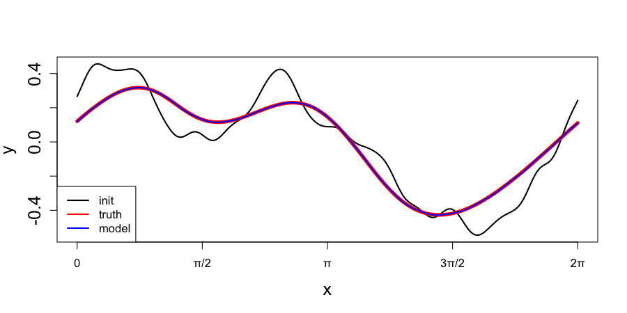

## RからPythonを使う

- [reticulate](https://rstudio.github.io/reticulate/)

```r
library(reticulate)

np <- import("numpy")
x <- np$load("x.npy")
```

- [tensorflow](https://cran.r-project.org/web/packages/tensorflow/index.html) へのインターフェースに利用されている。

## Rcpp

- RとC++のインターフェース
- 順行・勾配計算はCoDiPack
- フレームワークのオーバーヘッドを回避して高速化
- Rパッケージoptimxの`nvm`
- 真値: $(r,\sigma, \beta) = (32, 10, 8/3),\, (X, Y, Z) = (1, 3, 5)$
- 第一推定値: `30 11 2 1.1 3.3 5.5`
- torch for R: 62回 `32. 10.00 2.667 0.8989 3.128 5.012`
- nvm: 358回 機械精度で厳密に推定

## 表をきれいに

```r
library(tinytable)
trunc <- c(39, 79, 119, 239, 639, 1279)
nlon <- 3 * (trunc + 1)
nlat <- nlon / 2
df <- data.frame(trunc, nlon, nlat)
tab <- tt(df)
style_tt(tab, align="r")
```

| trunc | nlon | nlat |
| --- | --- | --- |
| 39 | 120 | 60 |
| 79 | 240 | 120 |
| 119 | 360 | 180 |
| 239 | 720 | 360 |
| 639 | 1920 | 960 |
| 1279 | 3840 | 1920 |

## Quarto

RMarkdownの進化形

- このスライドはMarkdownを拡張した記法で、  
  [Quarto](https://quarto.org/)を使って作成。
- 数式、RやPythonなどコードの実行。
- [Pandoc](https://pandoc.org/)を使ってHTML、LaTeX、Wordなどに出力。
- `bib`ファイルによる文献引用。

## まとめ

- Rは探索的データ解析に適した統計・描画環境。
- 海洋・気象・地理データの描画や解析もできる。
- 統計学者など専門家が作成した高品質なパッケージ。
- モデル、データ同化、機械学習のプロトタイプ作成。
- Pythonのモジュールの利用やC++による高速化も可能。

## 参考文献

Gagolewski, M., 2024: *[Deep R Programming](https://doi.org/10.5281/ZENODO.7490464)*. Zenodo,.

Gentleman, R., and D. Temple Lang, 2007: Statistical analyses and reproducible research. *Journal of Computational and Graphical Statistics*, **16**, 1–23, https://doi.org/10.1198/106186007X178663.

Li, Z., N. Kovachki, K. Azizzadenesheli, B. Liu, K. Bhattacharya, A. Stuart, and A. Anandkumar, 2021: Fourier Neural Operator for parametric partial differential equations. https://doi.org/10.48550/arXiv.2010.08895.

Marwick, B., C. Boettiger, and L. Mullen, 2018: Packaging data analytical work reproducibly using R (and friends). *The American Statistician*, **72**, 80–88, https://doi.org/10.1080/00031305.2017.1375986.

Schwab, M., N. Karrenbach, and J. Claerbout, 2000: Making scientific computations reproducible. *Computing in Science & Engineering*, **2**, 61–67, https://doi.org/10.1109/5992.881708.